# AI: Regression

## Regression usage on Fuel Consumption vs CO2 Emission data

In this project I use my own designed Regression and DataTable packages to predict a CO2 Emission based on car characteristics.

I'll walk you through this process of model definition, fine-tuning and evaluation. You might want to jump to the interesting section immediately.

1. Section 1- preparation
2. Section 2- model config
3. Section 3- first try
4. Section 4- real game
5. Section 5- more features - more fun
6. Section 6- results

# Introduction

I had developed my own Pandas-like simplified package data_reader.py to fetch different kind of data faster that Pandas can do and contains main features for Regression AI like data preparation for training/testing, split data, adding new features, creating combined one, ploting and many others.

In addition, to enhance my AI regression model's knowledge, I designed a regression.py package based on gradient descent technique to traing a (linear, non-linear, multi-variable) regression model with a various model parameters like number of iterations (epoch), learning rate (alpha) and regularization coefficient (regul). Moreover there is logs feature to monitor regression model learning and evaluation of its performance.

All these features and techniques I would like to show in this notebook.

For additional package usage, refer to doxy in its src code.

For that session, I'm going to use a FuelConsumtion.csv file, which contains table-like structure of data of how different parameters of the car impact on CO2 Emission. It might be interesting to try to predict how much particular car model will produce CO2.

# Section 1 - preparation

Import all necessary libs (yeah, matplotlib will be used just to make a nice visualization. And random lib as well).

```python
import data_reader as dr
import regression.regression as regression
import matplotlib.pyplot as plt
from mpl_toolkits.mplot3d import Axes3D
```

I had collected helper functions/stripts in helper_methods.py

```python
from helper_methods import *
```

To upload data, let's use DataTable (like dataFrame from Pandas) from data_reader.py.

```python
main_data_table = dr.DataTable("data/FuelConsumption.csv")
```

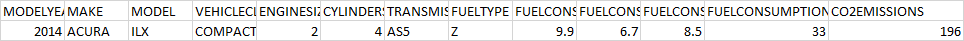

This DataTable is very suitable for a small-middle range data size, because with current implementation it stores all data into a main memory.

```python
main_data_table.head  # returns labels of each column
```

```
['MODELYEAR',
 'MAKE',
 'MODEL',
 'VEHICLECLASS',
 'ENGINESIZE',
 'CYLINDERS',
 'TRANSMISSION',
 'FUELTYPE',
 'FUELCONSUMPTION_CITY',
 'FUELCONSUMPTION_HWY',
 'FUELCONSUMPTION_COMB',
 'FUELCONSUMPTION_COMB_MPG',
 'CO2EMISSIONS']
```

```python
len(main_data_table)  # shows how many rows of data we have
```

```
1067
```

## Features and target selection

By default, there are no features and target pre-defined. Features - set of parameters we are going to use for our model to train it; target - set of outcome we desire to have from our trained model.

For the first time, I'm interested how engine size and fuel consumtion impact on CO2 emission.

For that, I select following features:

```python
# To define feature/s and target:
main_data_table.activate_features(["FUELCONSUMPTION_COMB_MPG", "ENGINESIZE"])
main_data_table.select_target("CO2EMISSIONS")
```

```
Feature FUELCONSUMPTION_COMB_MPG was added
Feature ENGINESIZE was added
Target CO2EMISSIONS was added
```

Let's draw it.

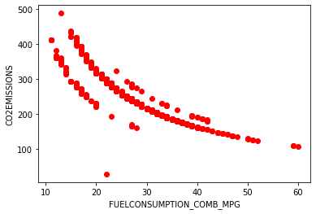

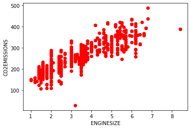

```python
main_data_table.plot(features2target=True)
```

Our features are defined like

```python
main_data_table.features
```

```
{'FUELCONSUMPTION_COMB_MPG': <data_reader.DataTable._DataColumn at 0x1061c30a0>,
 'ENGINESIZE': <data_reader.DataTable._DataColumn at 0x1061c3220>}
```

We can see that engine size can be filled with a straight line, what we cannot say about fuel consumption parameter. To showcase capabilities of my packages, I would like to select a parabolic curved feature.

Let's delete engine size feature from our training data set.

```python
main_data_table.deactivate_feature("ENGINESIZE")
```

```
Feature ENGINESIZE was disabled from the training set
```

```python
main_data_table.features
```

```
{'FUELCONSUMPTION_COMB_MPG': <data_reader.DataTable._DataColumn at 0x1061c30a0>}
```

## Training/CV/Testing data sets

DataTable supports data split onto training, cross-validation (direct model testing and selecting the best one) and testing data (for final model testing).

```python
main_data_table.split_data(0.6, 0.2, shuffle=True)
```

```
Shuffle was done
Data was split as follows: 0.6 training set, 0.2 cross-validation set and 0.2 test set
```

```python
# to fetch brand new data for AI purpose
training_data = main_data_table.get_training_data()  # returns (features data, target data)
cv_data = main_data_table.get_cv_data()
testing_data = main_data_table.get_testing_data()
```

```python
training_data[0][0:5] # feature data
```

```
[[27.0], [17.0], [39.0], [30.0], [23.0]]
```

```python
training_data[1][0:5] # target data
```

```
[242.0, 259.0, 166.0, 216.0, 283.0]
```

```python
data_labels = main_data_table.get_labels()  # to get labels of training/cv/testing data arrays
```

```python
data_labels
```

```
(['FUELCONSUMPTION_COMB_MPG'], 'CO2EMISSIONS')
```

Now data is prepared for first AI trials with 1 feature and 1 target.

# Section 2 - model config

```python
regression_model = regression.Regression()  # create model as an entity
regression_model.set_labels(data_labels)  # set labels of our data into the model
regression_model.set_training_data(training_data[0], training_data[1])  # and point this model to our data
regression_model.set_testing_data(cv_data[0], cv_data[1])  #
```

```
True
```

```python
regression_model
```

```
<regression.Regression at 0x12313cfa0>
```

# Section 3 - first try

In this section I'm going to play a little bit with my model and data we have. Let's set the following parameters:

```python
regression_model.ROUND_AFTER_COMA = 4  # simplify computation by rounding all results to 4 digits after coma
```

```python
# do first weight coefficients' initialization in range -10...10
regression_model.RANDOM_WEIGHT_INITIALIZATION = 10

# number of iteration 100
regression_model.epoch = 100

# learning rate 0.5
regression_model.alpha = 0.5

# regularization coefficient is 0
regression_model.regularization = 0
```

Now, we can fit our model with defined training data.

```python
coeffs = regression_model.fit()  # provide model training using defined training data set
```

```
Initiated coefficients are [5, -5]
Iteration 26 done
Iteration 51 done
Iteration 76 done
Training is completed with 100 iterations
```

```python
coeffs  # model's trained coefficients
```

```
[-9.212008495791602e+256, -2.62457033381171e+258]
```

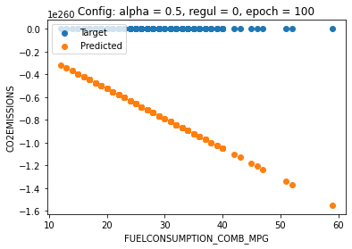

```python
cv_features, cv_target = cv_data
training_features, training_target = training_data
plot2d_target2predict(regression_model, cv_features, cv_target,
                      feature_name="FUELCONSUMPTION_COMB_MPG",
                      target_name="CO2EMISSIONS",
                      feature_idx = 0, loc_place="upper left")
```

Wow, it seems like we overshooted our global (and local as well) minimum of our model function and it has been decreasing so rapidly. Let's reduce learning coefficient significantly.

```python
regression_model.alpha = 0.01
```

```python
coeffs = regression_model.fit()
```

```
Initiated coefficients are [-5, -8]
Iteration 26 done
Iteration 51 done
Iteration 76 done
Training is completed with 100 iterations
```

```python
coeffs
```

```
[-1.1685903244157878e+81, -3.3294015080883016e+82]
```

Better, we just reduced coefficients from e+256 to e+81. Still, bad :D

Do we need reduce alpha even more? Let's introduce some regularization as well.

```python
regression_model.alpha = 0.001
regression_model.regularization = 0.2
```

```python
coeffs = regression_model.fit()
coeffs
```

```
Initiated coefficients are [2, 2]
Iteration 26 done
Iteration 51 done
Iteration 76 done
Training is completed with 100 iterations
```

```
[5.7349, 8.2525]
```

Looks much better. Let's try these coefficients.

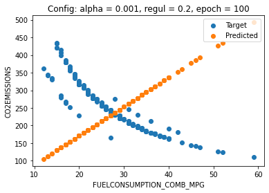

```python
plot2d_target2predict(regression_model, cv_features, cv_target,
                      feature_name="FUELCONSUMPTION_COMB_MPG",
                      target_name="CO2EMISSIONS",
                      feature_idx = 0, loc_place="upper right")
```

That seems like we didn't fit the model. Increase epoch and alpha?

```python
regression_model.alpha = 0.002
regression_model.epoch = 500
```

```python
coeffs = regression_model.fit()
coeffs
```

```
Initiated coefficients are [-7, -9]
Iteration 126 done
Iteration 251 done
Iteration 376 done
Training is completed with 500 iterations
```

```
[28.1806, 7.4646]
```

Still no. How about to initialize first coefficients in range -1...1?

```python
coeffs = regression_model.fit(scaled_coefficients=True)
coeffs
```

```
Initiated coefficients are [-0.4, 0.5]
Iteration 126 done
Iteration 251 done
Iteration 376 done
Training is completed with 500 iterations
```

```
[33.9735, 7.2613]
```

That's the moment when we have to scale our data

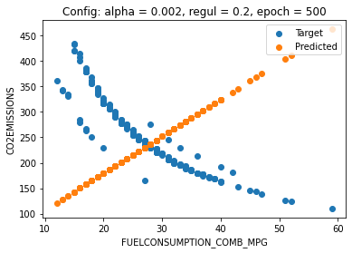

```python
plot2d_target2predict(regression_model, cv_features, cv_target,
                      feature_name="FUELCONSUMPTION_COMB_MPG",
                      target_name="CO2EMISSIONS",
                      feature_idx = 0, loc_place="upper right")
```

We faced a problem that we cannot select appropriate coefficients/parameters for our model to learn properly. At some moment we have overshoot, at another one - undershoot. May be data is still didn't ready?

# Section 4 - real game

In this section I will try to create the best 1 feature - 1 target model.

Let's scale our data as x = x / max(|X|), so the feature and the target will be in a range -1...1. To do so, we apply the following:

```python
main_data_table.max_scaling()
```

```
Column MODELYEAR was scaled
Column MAKE was scaled
Column MODEL was scaled
Column VEHICLECLASS was scaled
Column ENGINESIZE was scaled
Column CYLINDERS was scaled
Column TRANSMISSION was scaled
Column FUELTYPE was scaled
Column FUELCONSUMPTION_CITY was scaled
Column FUELCONSUMPTION_HWY was scaled
Column FUELCONSUMPTION_COMB was scaled
Column FUELCONSUMPTION_COMB_MPG was scaled
Column CO2EMISSIONS was scaled
```

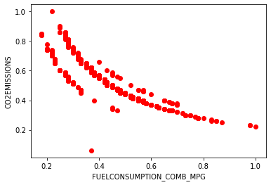

```python
main_data_table.plot(features2target=True)
```

indeed, as we can see data was scaled properly. Let's try with that data now.

```python
# regenerate training/cv/testing scaled data
scaled_training_data = main_data_table.get_training_data()
scaled_cv_data = main_data_table.get_cv_data()
scaled_testing_data = main_data_table.get_testing_data()
```

```python
regression_model.set_training_data(scaled_training_data[0], scaled_training_data[1])
regression_model.set_testing_data(scaled_cv_data[0], scaled_cv_data[1])
```

```
True
```

In additional, I'll enable logs' writing to showcase how the model was learning within time.

```python
regression_model.log_mode(True)
```

```
Log mode is enable
```

Let's try we the same config we had at very first time.

```python
regression_model.epoch = 100
regression_model.alpha = 0.5
regression_model.regularization = 0
```

```python
regression_model.fit()
```

```
Initiated coefficients are [-6, -3]
Iteration 26 done
Iteration 51 done
Iteration 76 done
Training is completed with 100 iterations
```

```
[0.7472, -0.5055]
```

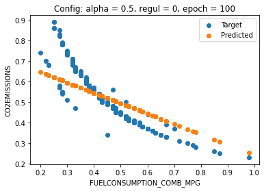

```python
cv_features, cv_target = scaled_cv_data
training_features, training_target = scaled_training_data
plot2d_target2predict(regression_model, cv_features, cv_target,
                      feature_name="FUELCONSUMPTION_COMB_MPG",
                      target_name="CO2EMISSIONS",
                      feature_idx = 0, loc_place="upper right")
```

Much better!! Regression model has method to evaluate trained model. There is mean absolute error metric as:

```python
regression_model.evaluation(scaled_cv_data, metric="MAE")
```

```
0.0635
```

Assuming all values scaled up to 1, we can say ignorantly that the model gives almost 94% accuracy.

Let's check what logs might show:

```python
logs1 = regression_model.get_logs()
```

```python
logs1
```

```
Logs of model settings alpha = 0.5, reg = 0
```

Let's use logs to analyse loss functions changes within a time.

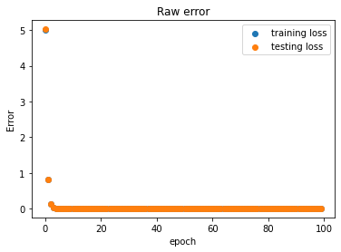

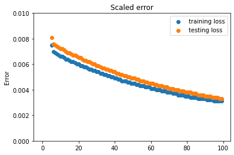

```python
plt.title("Raw error")
iterations = [x for x in range(logs1.iterations)]
cost_function_training = logs1.training_cf
cost_function_cv = logs1.testing_cf
plt.scatter(iterations, cost_function_training, label="training loss")
plt.scatter(iterations, cost_function_cv, label="testing loss")
plt.legend(loc="upper right")
plt.xlabel("epoch")
plt.ylabel("Error")
plt.show()

plt.title("Scaled error")
plt.ylim([0, 0.01])
plt.scatter(iterations, cost_function_training, label="training loss")
plt.scatter(iterations, cost_function_cv, label="testing loss")
plt.legend(loc="upper right")
plt.ylabel("Error")
plt.show()
```

Brilliant. It seems like we can increase alpha and number of iteration (epoch) to improve our model. But let's move forward.

## Square feature

We can add new feature to make the model line looks like parabolic. How about FUELCONSUMPTION_COMB_MPG^2?

To do so, we have to create a new feature data set as follows:

```python
main_data_table.add_new_feature("FUELCONSUMPTION_COMB_MPG", power=2)
```

```
New created feature FUELCONSUMPTION_COMB_MPG^(2) was added
This FUELCONSUMPTION_COMB_MPG^(2) feature is added to the list of training set
```

```python
main_data_table.features  # shows all enabled features
```

```
{'FUELCONSUMPTION_COMB_MPG': <data_reader.DataTable._DataColumn at 0x1061c30a0>,
 'FUELCONSUMPTION_COMB_MPG^(2)': <data_reader.DataTable._DataColumn at 0x12349c4c0>}
```

Also, we can set power = 0.5, which will give square root of selected feature. But for that time we are looking for power of 2.

```python
# regenerate training/cv/testing scaled data
scaled_training_data = main_data_table.get_training_data()
scaled_cv_data = main_data_table.get_cv_data()
scaled_testing_data = main_data_table.get_testing_data()

cv_features, cv_target = scaled_cv_data
training_features, training_target = scaled_training_data
```

```python
regression_model.set_training_data(scaled_training_data[0], scaled_training_data[1])
regression_model.set_testing_data(scaled_cv_data[0], scaled_cv_data[1])
```

```
True
```

```python
regression_model.epoch = 100
regression_model.alpha = 0.5
regression_model.regularization = 0
regression_model.fit()
```

```
Initiated coefficients are [1, 3, 2]
Iteration 26 done
Iteration 51 done
Iteration 76 done
Training is completed with 100 iterations
```

```
[0.313, 0.545, -0.1678]
```

```python
regression_model.coefficients
```

```
[0.313, 0.545, -0.1678]
```

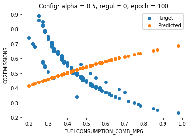

```python
plot2d_target2predict(regression_model, cv_features, cv_target,
                      feature_name="FUELCONSUMPTION_COMB_MPG",
                      target_name="CO2EMISSIONS",
                      feature_idx = 0, loc_place="upper right")
```

```python
regression_model.evaluation(scaled_cv_data, metric="MAE")
```

```
0.1502
```

Clearly we can see that the model is undertrained. How about to increase epoch?

```python
regression_model.epoch = 2000
```

```python
regression_model.fit()
```

```
Initiated coefficients are [-1, -4, -5]
Iteration 501 done
Iteration 1001 done
Iteration 1501 done
Training is completed with 2000 iterations
```

```
[0.7873, -0.2674, -0.683]
```

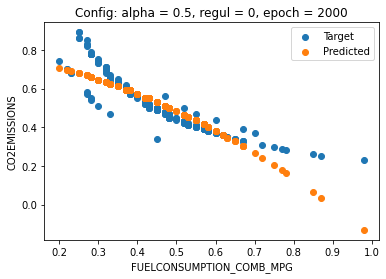

```python
plot2d_target2predict(regression_model, cv_features, cv_target,
                      feature_name="FUELCONSUMPTION_COMB_MPG",
                      target_name="CO2EMISSIONS",
                      feature_idx = 0, loc_place="upper right")
```

```python
regression_model.evaluation(scaled_cv_data, metric="MAE")
```

```
0.0468
```

Great! Now it looks more to what we want. But still it's not perfect. At first look we can provide some regularization to reduce square power.

Let's figure out what we can do.

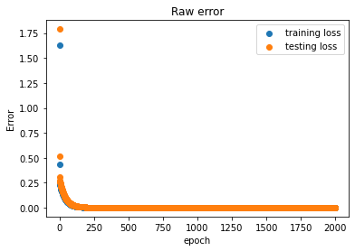

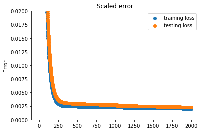

```python
logs_0alph5_0regul_2000epoch = regression_model.get_logs()
logs1 = logs_0alph5_0regul_2000epoch
plt.title("Raw error")
iterations = [x for x in range(logs1.iterations)]
cost_function_training = logs1.training_cf
cost_function_cv = logs1.testing_cf
plt.scatter(iterations, cost_function_training, label="training loss")
plt.scatter(iterations, cost_function_cv, label="testing loss")
plt.legend(loc="upper right")
plt.xlabel("epoch")
plt.ylabel("Error")
plt.show()

plt.title("Scaled error")
plt.ylim([0, 0.02])
plt.scatter(iterations, cost_function_training, label="training loss")
plt.scatter(iterations, cost_function_cv, label="testing loss")
plt.legend(loc="upper right")
plt.ylabel("Error")
plt.show()
```

From loss functions analysis we can see that epoch >= 1500 is not necessary, so it just wastes a time. Let's dive into alpha and regul parameters more.

```python
regression_model.epoch = 1500
regression_model.alpha = 0.6
regression_model.regularization = 0.1
regression_model.fit()
```

```
Initiated coefficients are [9, -8, -6]
Iteration 376 done
Iteration 751 done
Iteration 1126 done
Training is completed with 1500 iterations
```

```
[1.1425, -1.8649, 0.979]
```

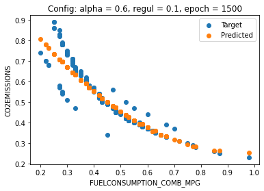

```python
plot2d_target2predict(regression_model, cv_features, cv_target,
                      feature_name="FUELCONSUMPTION_COMB_MPG",
                      target_name="CO2EMISSIONS",
                      feature_idx = 0, loc_place="upper right")
```

```python
regression_model.evaluation(scaled_cv_data, metric="MAE")
```

```
0.0275
```

```python
regression_model.evaluation(scaled_testing_data, metric="MAE")
```

```
0.032
```

## 1 feature - 1 target model results

### The best trained model is:

CO2EMISSIONS = 1.1425 - 1.8649 *FUELCONSUMPTION_COMB_MPG + 0.979* FUELCONSUMPTION_COMB_MPG^2

which gives only 0.0275 MAE or 2.75% error. Let's store this model for further usage.

```python
model_1_1 = regression_model
model_1_1.coefficients
```

```
[1.1425, -1.8649, 0.979]
```

# Section 5 - more features - more fun

How about to add more features into our model? What minimum MAE we might get? Let's explore.

In this section I'm going to build more complex model with way more features than it was before.

Let's create a new brand new model, where additional features will be applied.

```python
model_all = regression.Regression()
```

We might use the same scaled data. Let's add new features.

```python
# current enabled features are:
main_data_table.features
```

```
{'FUELCONSUMPTION_COMB_MPG': <data_reader.DataTable._DataColumn at 0x1061c30a0>,
 'FUELCONSUMPTION_COMB_MPG^(2)': <data_reader.DataTable._DataColumn at 0x12349c4c0>}
```

```python
main_data_table.head
```

```
['MODELYEAR',
 'MAKE',
 'MODEL',
 'VEHICLECLASS',
 'ENGINESIZE',
 'CYLINDERS',
 'TRANSMISSION',
 'FUELTYPE',
 'FUELCONSUMPTION_CITY',
 'FUELCONSUMPTION_HWY',
 'FUELCONSUMPTION_COMB',
 'FUELCONSUMPTION_COMB_MPG',
 'CO2EMISSIONS',
 'FUELCONSUMPTION_COMB_MPG^(2)']
```

Which features might be suitable for us? Which one might improve the quality of the model prediction? Let's plot data to find it out.

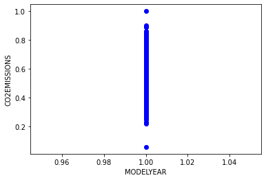

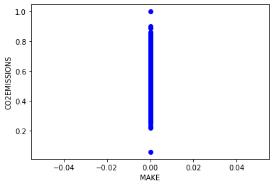

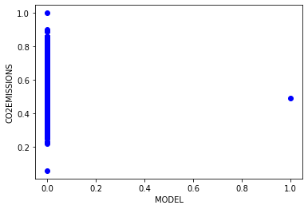

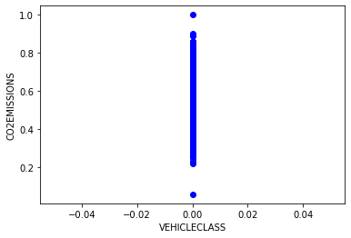

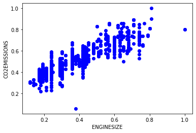

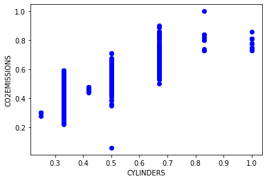

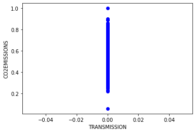

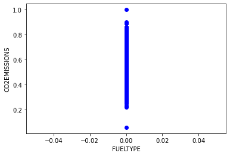

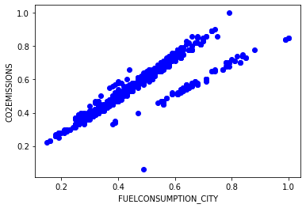

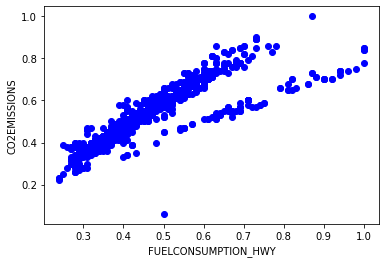

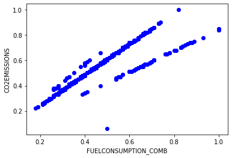

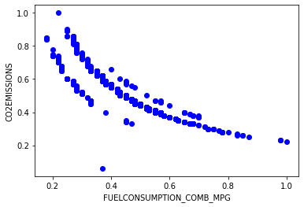

[1 more figures not shown]

```python
main_data_table.plot(all2target=True)
```

We can see that CO2 emission is highly dependent on Engine Size, Cylinders and Fuel Consumption in different variations.

Take a note, that other pictures with straight lines or 1 axisX value means that this data is not numerical.

```python
main_data_table.activate_features(["ENGINESIZE", "CYLINDERS", "FUELCONSUMPTION_COMB"])
```

```
Feature ENGINESIZE was added
Feature CYLINDERS was added
Feature FUELCONSUMPTION_COMB was added
```

```python
# list of enabled features are:
main_data_table.features
```

```
{'FUELCONSUMPTION_COMB_MPG': <data_reader.DataTable._DataColumn at 0x1061c30a0>,
 'FUELCONSUMPTION_COMB_MPG^(2)': <data_reader.DataTable._DataColumn at 0x12349c4c0>,
 'ENGINESIZE': <data_reader.DataTable._DataColumn at 0x1061c3220>,
 'CYLINDERS': <data_reader.DataTable._DataColumn at 0x1061c3160>,
 'FUELCONSUMPTION_COMB': <data_reader.DataTable._DataColumn at 0x1061c32b0>}
```

```python
# Regenerate new data for training/testing
scaled_training_data = main_data_table.get_training_data()
scaled_cv_data = main_data_table.get_cv_data()
scaled_testing_data = main_data_table.get_testing_data()
data_labels = main_data_table.get_labels()
```

```python
model_all.set_labels(data_labels)
model_all.set_training_data(scaled_training_data[0], scaled_training_data[1])
model_all.set_testing_data(scaled_cv_data[0], scaled_cv_data[1])
model_all.labels
```

```
(['FUELCONSUMPTION_COMB_MPG',
  'FUELCONSUMPTION_COMB_MPG^(2)',
  'ENGINESIZE',
  'CYLINDERS',
  'FUELCONSUMPTION_COMB'],
 'CO2EMISSIONS')
```

```python
model_all.set_model_parameters(alpha=0.3, regularization=0.1, epoch=1500)
model_all.RANDOM_WEIGHT_INITIALIZATION = 10
```

```python
model_all.fit()
```

```
Initiated coefficients are [1, 10, -2, -8, 10, 10]
Iteration 376 done
Iteration 751 done
Iteration 1126 done
Training is completed with 1500 iterations
```

```
[-5.09, 6.99, -3.54, -8.33, 7.47, 6.67]
```

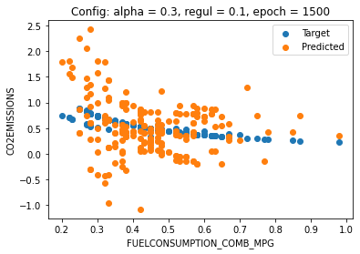

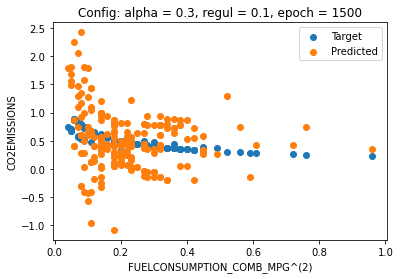

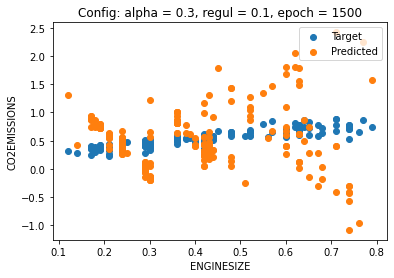

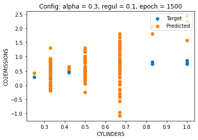

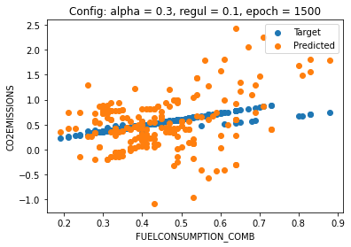

```python
cv_features, cv_target = scaled_cv_data[0], scaled_cv_data[1]
features, target = model_all.labels
for feature_idx in range(len(features)):
        plot2d_target2predict(model_all, cv_features, cv_target,
                              feature_name=features[feature_idx],
                              target_name=target, feature_idx=feature_idx, loc_place="upper right")
```

```python
model_all.evaluation(scaled_testing_data)
```

```
0.36
```

Well, it can be better! Let's fine-tune the model.

```python
model_all.set_model_parameters(alpha=0.7, regularization=0.1, epoch=1500)
model_all.fit(scaled_coefficients=True)
```

```
Initiated coefficients are [0.9, 0.4, -0.5, -0.2, 0.3, 0.7]
Iteration 376 done
Iteration 751 done
Iteration 1126 done
Training is completed with 1500 iterations
```

```
[0.37, 0.13, -0.61, -0.24, 0.18, 0.53]
```

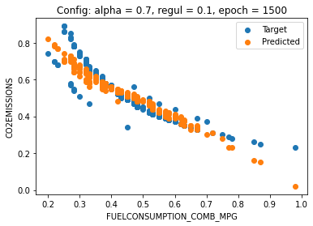

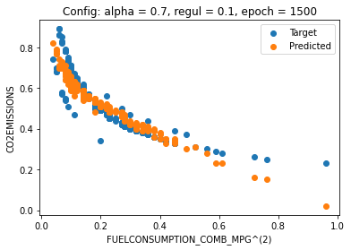

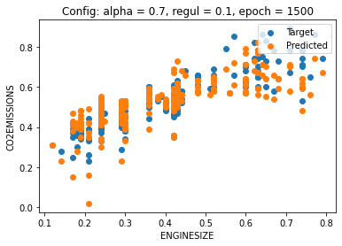

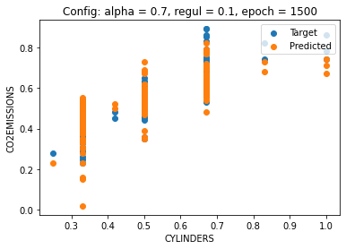

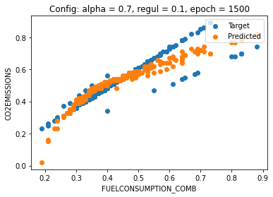

```python
for feature_idx in range(len(features)):
        plot2d_target2predict(model_all, cv_features, cv_target,
                              feature_name=features[feature_idx],
                              target_name=target, feature_idx=feature_idx, loc_place="upper right")
```

```python
model_all.evaluation(scaled_testing_data)
```

```
0.05
```

# Section 6 - results

Per this work we used gradient descent algorithms to train the model with different features, learning rate and regularization parameters to find our how they impact on the model's learning process.

We could predict CO2 emission within 5% (from max given target value) error based on mean absolute metric and using related features!! We can improve this model even further (once I got 4%), but it's out of the scope of this work.

But the interesting thing is that with only Fuel Consumtion parameter we could predict CO2 emission only within 3% error! It shows how feature's selection is important.